# happiness

```python
#imports, file load, and print header of raw data

import pandas as pd
import numpy as np
import statistics
import matplotlib.pyplot as plt
from scipy.stats import ttest_ind
from scipy import stats
import seaborn as sns
%matplotlib inline

#import data from local file - assumed to be in same directory as this workbook
h = pd.read_csv('2017.csv')
h.set_index("Country", inplace=True)
```

```python
h.head()
```

| Country | Happiness.Rank | Happiness.Score | Whisker.high | Whisker.low | Economy..GDP.per.Capita. | Family | Health..Life.Expectancy. | Freedom | Generosity | Trust..Government.Corruption. | Dystopia.Residual |
| --- | --- | --- | --- | --- | --- | --- | --- | --- | --- | --- | --- |
| Norway | 1 | 7.537 | 7.594445 | 7.479556 | 1.616463 | 1.533524 | 0.796667 | 0.635423 | 0.362012 | 0.315964 | 2.277027 |
| Denmark | 2 | 7.522 | 7.581728 | 7.462272 | 1.482383 | 1.551122 | 0.792566 | 0.626007 | 0.355280 | 0.400770 | 2.313707 |
| Iceland | 3 | 7.504 | 7.622030 | 7.385970 | 1.480633 | 1.610574 | 0.833552 | 0.627163 | 0.475540 | 0.153527 | 2.322715 |
| Switzerland | 4 | 7.494 | 7.561772 | 7.426227 | 1.564980 | 1.516912 | 0.858131 | 0.620071 | 0.290549 | 0.367007 | 2.276716 |
| Finland | 5 | 7.469 | 7.527542 | 7.410458 | 1.443572 | 1.540247 | 0.809158 | 0.617951 | 0.245483 | 0.382612 | 2.430182 |

## Single Variable Plots

### Histogram with KDE

Pros: Good simple, very commonly understood plot for describing the distribution, with an added best fit curve.  
Cons: Gives a sense of the distribution but doesn't put numbers on the mean, quartiles.

### Violin

Pros: Combines the familiar historgram view and a box-plot-like line plot, for a similar richness of description to the boxxplot + swarm.  
Cons: Not as well known as the histogram.

### Histogram with best-fit Gamma curve

Pros: Same commonly understood historgram, with a visual overlay of a gamma curve, showign that it "kinda is like a gamma."  
Cons: Requires some additional explanation, as compared to the historgram and KDE. Might even be confused for the historgram + KDE without explanation.

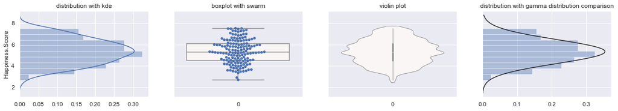

```python
# Choose one variable and plot that variable four different way

sns.set()

plt.figure(figsize=(20, 3))

plt.subplot(1,4,1, title ="distribution with kde")
ax1 = sns.distplot(h["Happiness.Score"], vertical=True)


plt.subplot(1,4,2, title ="boxplot with swarm", sharey=ax1)
ax2 = sns.boxplot(data=h["Happiness.Score"], palette="vlag")
ax2 = sns.swarmplot(data=h["Happiness.Score"], size=5, color="b", linewidth=0)
ax2.tick_params(labelleft='off')

plt.subplot(1,4,3,sharey=ax1, title ="violin plot")
ax3=sns.violinplot(data=h["Happiness.Score"], palette="vlag", bw=.2, cut=1, linewidth=1)
ax3.tick_params(labelleft=False)

plt.subplot(1,4,4, sharey=ax1, title ="distribution with gamma distribution comparison")
ax4 = sns.distplot(h["Happiness.Score"], kde=False, fit=stats.gamma, vertical=True)
ax4.tick_params(labelleft=False)
ax4.set_ylabel("")
```

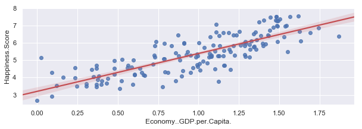

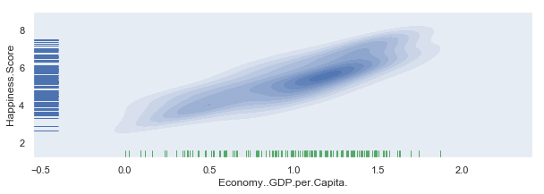

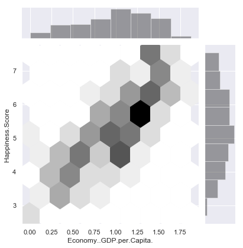

```python
# Choose two continuous variables, and plot them three different ways.

plt.figure(figsize=(10, 3))

# plt.subplot(1,2,1)
# ax1 = sns.regplot(x="Economy..GDP.per.Capita.", y="Happiness.Score", data=h, fit_reg=False)

#plt.subplot(1,2,2)
ax2 = sns.regplot(x="Economy..GDP.per.Capita.", y="Happiness.Score", data=h, line_kws={"color":"r"})

plt.figure(figsize=(10, 3))
ax3 = sns.kdeplot(h["Economy..GDP.per.Capita."], h["Happiness.Score"], n_levels=10, shade=True)
sns.rugplot(h["Economy..GDP.per.Capita."], color="g", ax=ax3)
sns.rugplot(h["Happiness.Score"], vertical=True, ax=ax3);


sns.jointplot(x=h["Economy..GDP.per.Capita."], y=h["Happiness.Score"], kind="hex", color="k");
```

```python
#import data from local file - assumed to be in same directory as this workbook
su = pd.read_csv('suicide.csv')
su.head()
```

|  | country | year | sex | age | suicides_no | population | suicides/100k pop | country-year | HDI for year | gdp_for_year ($) | gdp_per_capita ($) | generation |
| --- | --- | --- | --- | --- | --- | --- | --- | --- | --- | --- | --- | --- |
| 0 | Albania | 1987 | male | 15-24 years | 21 | 312900 | 6.71 | Albania1987 | NaN | 2,156,624,900 | 796 | Generation X |
| 1 | Albania | 1987 | male | 35-54 years | 16 | 308000 | 5.19 | Albania1987 | NaN | 2,156,624,900 | 796 | Silent |
| 2 | Albania | 1987 | female | 15-24 years | 14 | 289700 | 4.83 | Albania1987 | NaN | 2,156,624,900 | 796 | Generation X |
| 3 | Albania | 1987 | male | 75+ years | 1 | 21800 | 4.59 | Albania1987 | NaN | 2,156,624,900 | 796 | G.I. Generation |
| 4 | Albania | 1987 | male | 25-34 years | 9 | 274300 | 3.28 | Albania1987 | NaN | 2,156,624,900 | 796 | Boomers |

```python
su.count()
```

```
country               27820
year                  27820
sex                   27820
age                   27820
suicides_no           27820
population            27820
suicides/100k pop     27820
country-year          27820
HDI for year           8364
 gdp_for_year ($)     27820
gdp_per_capita ($)    27820
generation            27820
dtype: int64
```

```python
su.describe()
```

|  | year | suicides_no | population | suicides/100k pop | HDI for year | gdp_per_capita ($) |
| --- | --- | --- | --- | --- | --- | --- |
| count | 27820.000000 | 27820.000000 | 2.782000e+04 | 27820.000000 | 8364.000000 | 27820.000000 |
| mean | 2001.258375 | 242.574407 | 1.844794e+06 | 12.816097 | 0.776601 | 16866.464414 |
| std | 8.469055 | 902.047917 | 3.911779e+06 | 18.961511 | 0.093367 | 18887.576472 |
| min | 1985.000000 | 0.000000 | 2.780000e+02 | 0.000000 | 0.483000 | 251.000000 |
| 25% | 1995.000000 | 3.000000 | 9.749850e+04 | 0.920000 | 0.713000 | 3447.000000 |
| 50% | 2002.000000 | 25.000000 | 4.301500e+05 | 5.990000 | 0.779000 | 9372.000000 |
| 75% | 2008.000000 | 131.000000 | 1.486143e+06 | 16.620000 | 0.855000 | 24874.000000 |
| max | 2016.000000 | 22338.000000 | 4.380521e+07 | 224.970000 | 0.944000 | 126352.000000 |

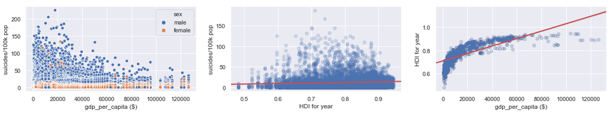

```python
# Choose one continuous variable and one categorical variable, and plot them six different ways.↔
```

#### Observations:

- Suicide Rates appear to be more variable in lower income and higer HDI countries
- HDI rises dramatically with GDP per capita up to 10k/yr, rises more gradually up to about 60k per year, and seems to chage very litte >60k

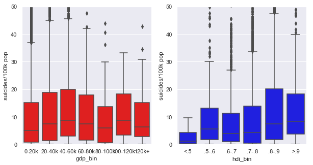

```python
# Choose one continuous variable and one categorical variable, and plot them six different ways.↔
```

```python
#an aside...is there any significant relationship between income and gdp/capita? ↔
```

```
comparing <20 to 20-40:
Ttest_indResult(statistic=-3.3865362030079504, pvalue=0.0007106085224398641)
comparing 20-40 to 40-60:
Ttest_indResult(statistic=0.6524068002628388, pvalue=0.5141663708152278)
comparing <20 and 40-60:
Ttest_indResult(statistic=-2.115623252878851, pvalue=0.03444590278674078)
comparing <20 and 60-80:
Ttest_indResult(statistic=3.121304737722222, pvalue=0.0018862843672812248)
comparing <20 and 80-100:
Ttest_indResult(statistic=3.3611009264613156, pvalue=0.0008956440907816354)
comparing <20 and 100-120:
Ttest_indResult(statistic=1.2915796677917628, pvalue=0.1988904028582407)
comparing <20 and 120+:
Ttest_indResult(statistic=1.6403055701466613, pvalue=0.10749508096653838)
```

```python
#another aside....is there any significant relationship between income and gdp/capita? ↔
```

```
comparing <5 to 5-6:
Ttest_indResult(statistic=-5.721649227399647, pvalue=6.16200179733028e-07)
comparing <5 and 6-7:
Ttest_indResult(statistic=-6.572439599497228, pvalue=7.475256042731019e-06)
comparing <5 and 7-8:
Ttest_indResult(statistic=-8.560762566818756, pvalue=5.929142960843285e-07)
comparing <5 and 8-9:
Ttest_indResult(statistic=-10.991521678178685, pvalue=3.19507536040091e-08)
comparing <5 and >9:
Ttest_indResult(statistic=-8.481664749524233, pvalue=5.125622631229491e-07)
comparing <8 and >8:
Ttest_indResult(statistic=-6.79652101912513, pvalue=1.1481315343482047e-11)
```

#### Observations

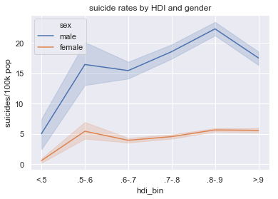

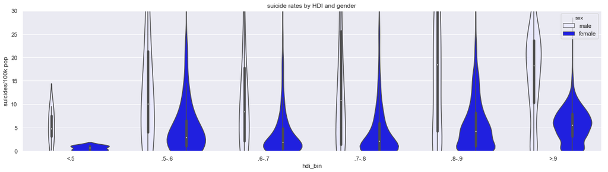

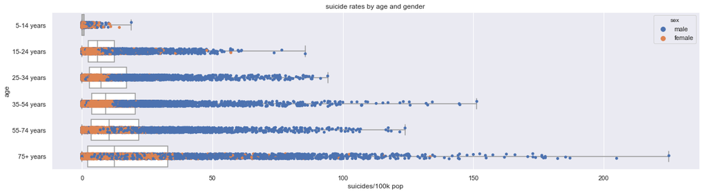

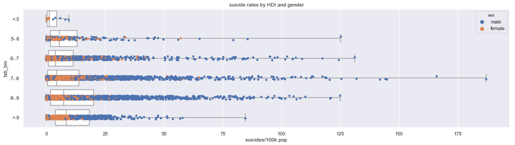

```python
#continuing the two-variable plotting exercise↔
```

#### Observations

- The relationship seems to hold for men and women
- The violin plot does s great job of showing the distribution shape differences between gender
- The categorical scatterplot is not all that useful here
- The line plot is best for showing the trend across categories - since these categories have directionality.
- The seaborn swarm plot doesn't work well with this size of data, it seems. It seems to break jupyter - i.e. nothing will execute after trying to execute the swarm.

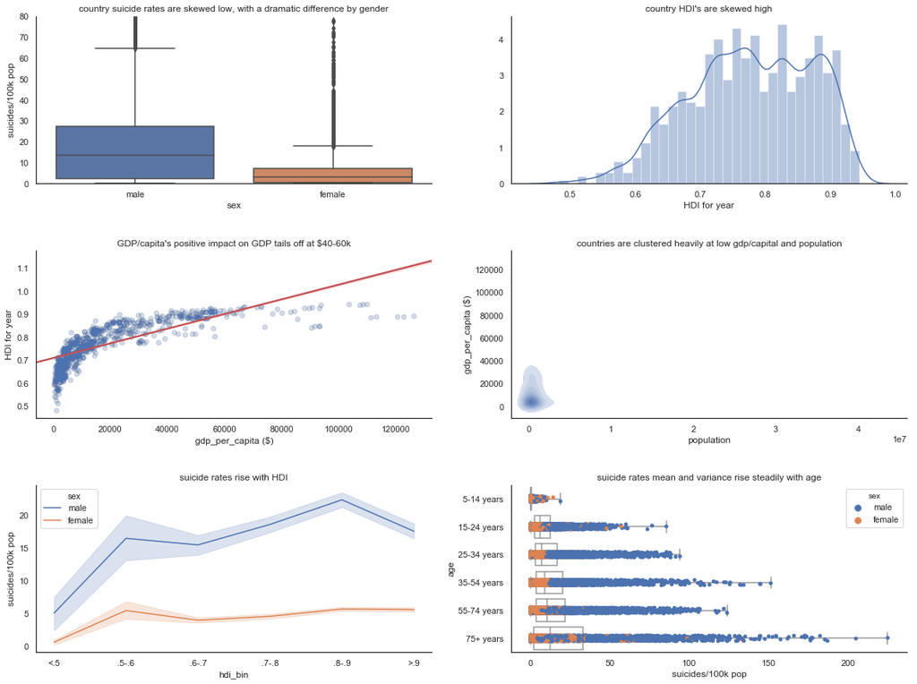

```python
# Find a dataset with at least four continuous variables and one categorical variable. ↔
```

# Assignment ends here - the rest is playing :)

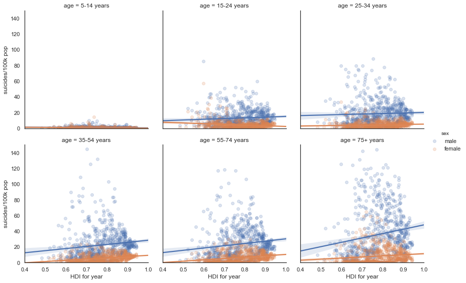

```python
#exploring FacetGrid....↔
```

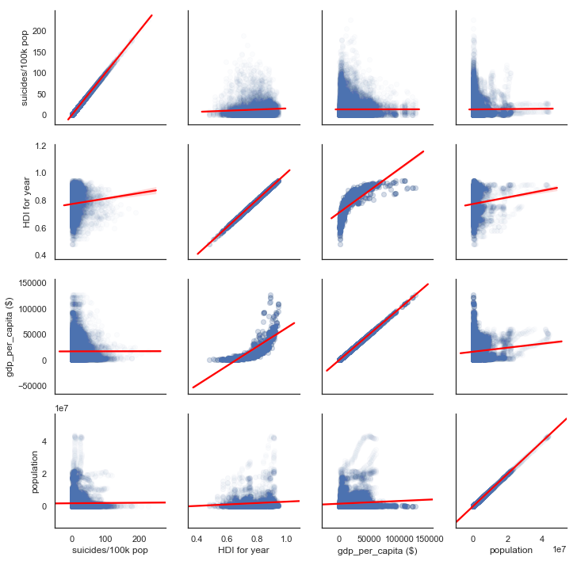

```python
#exploring pair grids of all the continuous variables↔
```

```python
#playing with looping through a dataframe to display lots of plots
#doesn't look very good over multiple columns
# fig, axs = plt.subplots(1, 4, figsize=(20,5))
# i = 1
# for column in su_sub:
#     sns.distplot(su[column].dropna(), ax=fig.add_subplot(2,2,i))
#     i+=1
#plt.show()
```